# Rottnest comparison

2023-10-09

This is the same notebook as 100_species, but we look at the rottnest queryset. This should be slightly harder. # Setup

```r
knitr::opts_chunk$set(warning = FALSE)

source('code/helpers.R')
library(tidyverse)
library(forcats)
library(cowplot)
library(ggupset)
library(RColorBrewer)
library(patchwork)
library(vegan)
library(pheatmap)
library(broom)
```

```r
data <- targets::tar_read(merged_all_results)
# rename BLAST to BLAST97 to differentiate from BLAST100 (percentage identity in both cases)
data <- data |> mutate(Type = str_replace(Type, '^BLAST$', 'BLAST97'))
truth <- targets::tar_read(truth_set_data)
```

```r
table(data$Type)
```

```
##
##    BLAST100     BLAST97  Kraken_0.0 Kraken_0.05  Kraken_0.1    Metabuli
##        9025       13893       82560       82560       55040       32545
##     MMSeqs2      Mothur         NBC      Qiime2     VSEARCH
##       89856       87048       98280       13229       13331
```

Let’s remove the >0.2 Kraken runs, those are too strict

```r
data <- data |> filter(!Type %in% c('Kraken_0.2', 'Kraken_0.3', 'Kraken_0.4', 'Kraken_0.5', 'Kraken_0.6', 'Kraken_0.7', 'Kraken_0.8', 'Kraken_0.9'))
```

Made a mistake- Metabuli’s Database is misspelled

```r
data <- data |> mutate(Subject = str_replace_all(Subject, pattern = '_ref.fasta', replacement=''))
```

```r
table(data$Query)
```

```
##
##                                                                                KWest_16S_PooledTrue.fa
##                                                                                                 132865
##   make_12s_16s_simulated_reads_5-BetterDatabaseARTSimulation_runEDNAFLOW_12S_Lulu_RESULTS_dada2_asv.fa
##                                                                                                  54092
## make_12s_16s_simulated_reads_5-BetterDatabaseARTSimulation_runEDNAFLOW_12S_noLulu_RESULTS_dada2_asv.fa
##                                                                                                  54092
##   make_12s_16s_simulated_reads_5-BetterDatabaseARTSimulation_runEDNAFLOW_16S_Lulu_RESULTS_dada2_asv.fa
##                                                                                                  52001
## make_12s_16s_simulated_reads_5-BetterDatabaseARTSimulation_runEDNAFLOW_16S_noLulu_RESULTS_dada2_asv.fa
##                                                                                                  52001
##                               make_12s_16s_simulated_reads_6-fakeGenes_GreenGenes_RESULTS_dada2_asv.fa
##                                                                                                  44774
##                                   make_12s_16s_simulated_reads_6-fakeGenes_Random_RESULTS_dada2_asv.fa
##                                                                                                  45205
##                     make_12s_16s_simulated_reads_7-Lutjanids_Mock_runEDNAFlow_12S_RESULTS_dada2_asv.fa
##                                                                                                  13384
##                     make_12s_16s_simulated_reads_7-Lutjanids_Mock_runEDNAFlow_16S_RESULTS_dada2_asv.fa
##                                                                                                  14233
##                           make_12s_16s_simulated_reads_8-Rottnest_runEDNAFLOW_12S_RESULTS_dada2_asv.fa
##                                                                                                  55763
##                           make_12s_16s_simulated_reads_8-Rottnest_runEDNAFLOW_16S_RESULTS_dada2_asv.fa
##                                                                                                  58957
```

# Rottnest species

## Check 12S results

```r
table(data$Subject)
```

```
##
##                                                    12s_v010_final.fasta
##                                                                    8327
##    12s_v010_final.fasta_Taxonomies.CountedFams.txt_fifty_subset_1.fasta
##                                                                    7830
##   12s_v010_final.fasta_Taxonomies.CountedFams.txt_fifty_subset_10.fasta
##                                                                    7687
##    12s_v010_final.fasta_Taxonomies.CountedFams.txt_fifty_subset_2.fasta
##                                                                    7783
##    12s_v010_final.fasta_Taxonomies.CountedFams.txt_fifty_subset_3.fasta
##                                                                    7849
##    12s_v010_final.fasta_Taxonomies.CountedFams.txt_fifty_subset_4.fasta
##                                                                    7723
##    12s_v010_final.fasta_Taxonomies.CountedFams.txt_fifty_subset_5.fasta
##                                                                    7854
##    12s_v010_final.fasta_Taxonomies.CountedFams.txt_fifty_subset_6.fasta
##                                                                    7574
##    12s_v010_final.fasta_Taxonomies.CountedFams.txt_fifty_subset_7.fasta
##                                                                    7628
##    12s_v010_final.fasta_Taxonomies.CountedFams.txt_fifty_subset_8.fasta
##                                                                    7973
##    12s_v010_final.fasta_Taxonomies.CountedFams.txt_fifty_subset_9.fasta
##                                                                    7930
##  12s_v010_final.fasta_Taxonomies.CountedFams.txt_seventy_subset_1.fasta
##                                                                    8112
## 12s_v010_final.fasta_Taxonomies.CountedFams.txt_seventy_subset_10.fasta
##                                                                    7938
##  12s_v010_final.fasta_Taxonomies.CountedFams.txt_seventy_subset_2.fasta
##                                                                    7926
##  12s_v010_final.fasta_Taxonomies.CountedFams.txt_seventy_subset_3.fasta
##                                                                    8113
##  12s_v010_final.fasta_Taxonomies.CountedFams.txt_seventy_subset_4.fasta
##                                                                    7981
##  12s_v010_final.fasta_Taxonomies.CountedFams.txt_seventy_subset_5.fasta
##                                                                    7967
##  12s_v010_final.fasta_Taxonomies.CountedFams.txt_seventy_subset_6.fasta
##                                                                    7866
##  12s_v010_final.fasta_Taxonomies.CountedFams.txt_seventy_subset_7.fasta
##                                                                    7997
##  12s_v010_final.fasta_Taxonomies.CountedFams.txt_seventy_subset_8.fasta
```

[output cut: 138 more lines]

```
##                                                                    1720
##    c01_v03_final.fasta_Taxonomies.CountedFams.txt_thirty_subset_4.fasta
##                                                                    1720
##    c01_v03_final.fasta_Taxonomies.CountedFams.txt_thirty_subset_5.fasta
##                                                                    1720
##    c01_v03_final.fasta_Taxonomies.CountedFams.txt_thirty_subset_6.fasta
##                                                                    1720
##    c01_v03_final.fasta_Taxonomies.CountedFams.txt_thirty_subset_7.fasta
##                                                                    1720
##    c01_v03_final.fasta_Taxonomies.CountedFams.txt_thirty_subset_8.fasta
##                                                                    1720
##    c01_v03_final.fasta_Taxonomies.CountedFams.txt_thirty_subset_9.fasta
##                                                                    1720
##                                                    c01_v03_HmmCut.fasta
##                                                                    1720
```

```r
table(data$Subject)
```

```
##
##                                                    12s_v010_final.fasta
##                                                                    8327
##    12s_v010_final.fasta_Taxonomies.CountedFams.txt_fifty_subset_1.fasta
##                                                                    7830
##   12s_v010_final.fasta_Taxonomies.CountedFams.txt_fifty_subset_10.fasta
##                                                                    7687
##    12s_v010_final.fasta_Taxonomies.CountedFams.txt_fifty_subset_2.fasta
##                                                                    7783
##    12s_v010_final.fasta_Taxonomies.CountedFams.txt_fifty_subset_3.fasta
##                                                                    7849
##    12s_v010_final.fasta_Taxonomies.CountedFams.txt_fifty_subset_4.fasta
##                                                                    7723
##    12s_v010_final.fasta_Taxonomies.CountedFams.txt_fifty_subset_5.fasta
##                                                                    7854
##    12s_v010_final.fasta_Taxonomies.CountedFams.txt_fifty_subset_6.fasta
##                                                                    7574
##    12s_v010_final.fasta_Taxonomies.CountedFams.txt_fifty_subset_7.fasta
##                                                                    7628
##    12s_v010_final.fasta_Taxonomies.CountedFams.txt_fifty_subset_8.fasta
##                                                                    7973
##    12s_v010_final.fasta_Taxonomies.CountedFams.txt_fifty_subset_9.fasta
##                                                                    7930
##  12s_v010_final.fasta_Taxonomies.CountedFams.txt_seventy_subset_1.fasta
##                                                                    8112
## 12s_v010_final.fasta_Taxonomies.CountedFams.txt_seventy_subset_10.fasta
##                                                                    7938
##  12s_v010_final.fasta_Taxonomies.CountedFams.txt_seventy_subset_2.fasta
##                                                                    7926
##  12s_v010_final.fasta_Taxonomies.CountedFams.txt_seventy_subset_3.fasta
##                                                                    8113
##  12s_v010_final.fasta_Taxonomies.CountedFams.txt_seventy_subset_4.fasta
##                                                                    7981
##  12s_v010_final.fasta_Taxonomies.CountedFams.txt_seventy_subset_5.fasta
##                                                                    7967
##  12s_v010_final.fasta_Taxonomies.CountedFams.txt_seventy_subset_6.fasta
##                                                                    7866
##  12s_v010_final.fasta_Taxonomies.CountedFams.txt_seventy_subset_7.fasta
##                                                                    7997
##  12s_v010_final.fasta_Taxonomies.CountedFams.txt_seventy_subset_8.fasta
```

[output cut: 138 more lines]

```
##                                                                    1720
##    c01_v03_final.fasta_Taxonomies.CountedFams.txt_thirty_subset_4.fasta
##                                                                    1720
##    c01_v03_final.fasta_Taxonomies.CountedFams.txt_thirty_subset_5.fasta
##                                                                    1720
##    c01_v03_final.fasta_Taxonomies.CountedFams.txt_thirty_subset_6.fasta
##                                                                    1720
##    c01_v03_final.fasta_Taxonomies.CountedFams.txt_thirty_subset_7.fasta
##                                                                    1720
##    c01_v03_final.fasta_Taxonomies.CountedFams.txt_thirty_subset_8.fasta
##                                                                    1720
##    c01_v03_final.fasta_Taxonomies.CountedFams.txt_thirty_subset_9.fasta
##                                                                    1720
##                                                    c01_v03_HmmCut.fasta
##                                                                    1720
```

```r
twelveS_data <- data |> filter(Subject == '12s_v010_final.fasta')
sixteenS_data <- data |> filter(Subject == '16S_v04_final.fasta')
table(twelveS_data$Query)
```

```
##
##                                                                                KWest_16S_PooledTrue.fa
##                                                                                                   1827
##   make_12s_16s_simulated_reads_5-BetterDatabaseARTSimulation_runEDNAFLOW_12S_Lulu_RESULTS_dada2_asv.fa
##                                                                                                    947
## make_12s_16s_simulated_reads_5-BetterDatabaseARTSimulation_runEDNAFLOW_12S_noLulu_RESULTS_dada2_asv.fa
##                                                                                                    947
##   make_12s_16s_simulated_reads_5-BetterDatabaseARTSimulation_runEDNAFLOW_16S_Lulu_RESULTS_dada2_asv.fa
##                                                                                                    645
## make_12s_16s_simulated_reads_5-BetterDatabaseARTSimulation_runEDNAFLOW_16S_noLulu_RESULTS_dada2_asv.fa
##                                                                                                    645
##                               make_12s_16s_simulated_reads_6-fakeGenes_GreenGenes_RESULTS_dada2_asv.fa
##                                                                                                    594
##                                   make_12s_16s_simulated_reads_6-fakeGenes_Random_RESULTS_dada2_asv.fa
##                                                                                                    600
##                     make_12s_16s_simulated_reads_7-Lutjanids_Mock_runEDNAFlow_12S_RESULTS_dada2_asv.fa
##                                                                                                    229
##                     make_12s_16s_simulated_reads_7-Lutjanids_Mock_runEDNAFlow_16S_RESULTS_dada2_asv.fa
##                                                                                                    184
##                           make_12s_16s_simulated_reads_8-Rottnest_runEDNAFLOW_12S_RESULTS_dada2_asv.fa
##                                                                                                    977
##                           make_12s_16s_simulated_reads_8-Rottnest_runEDNAFLOW_16S_RESULTS_dada2_asv.fa
##                                                                                                    732
```

```r
table(sixteenS_data$Query)
```

```
##
##                                                                                KWest_16S_PooledTrue.fa
##                                                                                                   2766
##   make_12s_16s_simulated_reads_5-BetterDatabaseARTSimulation_runEDNAFLOW_12S_Lulu_RESULTS_dada2_asv.fa
##                                                                                                    720
## make_12s_16s_simulated_reads_5-BetterDatabaseARTSimulation_runEDNAFLOW_12S_noLulu_RESULTS_dada2_asv.fa
##                                                                                                    720
##   make_12s_16s_simulated_reads_5-BetterDatabaseARTSimulation_runEDNAFLOW_16S_Lulu_RESULTS_dada2_asv.fa
##                                                                                                    922
## make_12s_16s_simulated_reads_5-BetterDatabaseARTSimulation_runEDNAFLOW_16S_noLulu_RESULTS_dada2_asv.fa
##                                                                                                    922
##                               make_12s_16s_simulated_reads_6-fakeGenes_GreenGenes_RESULTS_dada2_asv.fa
##                                                                                                    594
##                                   make_12s_16s_simulated_reads_6-fakeGenes_Random_RESULTS_dada2_asv.fa
##                                                                                                    600
##                     make_12s_16s_simulated_reads_7-Lutjanids_Mock_runEDNAFlow_12S_RESULTS_dada2_asv.fa
##                                                                                                    178
##                     make_12s_16s_simulated_reads_7-Lutjanids_Mock_runEDNAFlow_16S_RESULTS_dada2_asv.fa
##                                                                                                    236
##                           make_12s_16s_simulated_reads_8-Rottnest_runEDNAFLOW_12S_RESULTS_dada2_asv.fa
##                                                                                                    738
##                           make_12s_16s_simulated_reads_8-Rottnest_runEDNAFLOW_16S_RESULTS_dada2_asv.fa
##                                                                                                   1061
```

```r
table(sixteenS_data$Subject)
```

```
##
## 16S_v04_final.fasta
##                9457
```

```r
twelveS_data_vs_12S_100 <- twelveS_data |>
  filter(Query == 'make_12s_16s_simulated_reads_8-Rottnest_runEDNAFLOW_12S_RESULTS_dada2_asv.fa')
sixteenS_data_vs_16S_100 <- sixteenS_data |>
  filter(Query == 'make_12s_16s_simulated_reads_8-Rottnest_runEDNAFLOW_16S_RESULTS_dada2_asv.fa' )
```

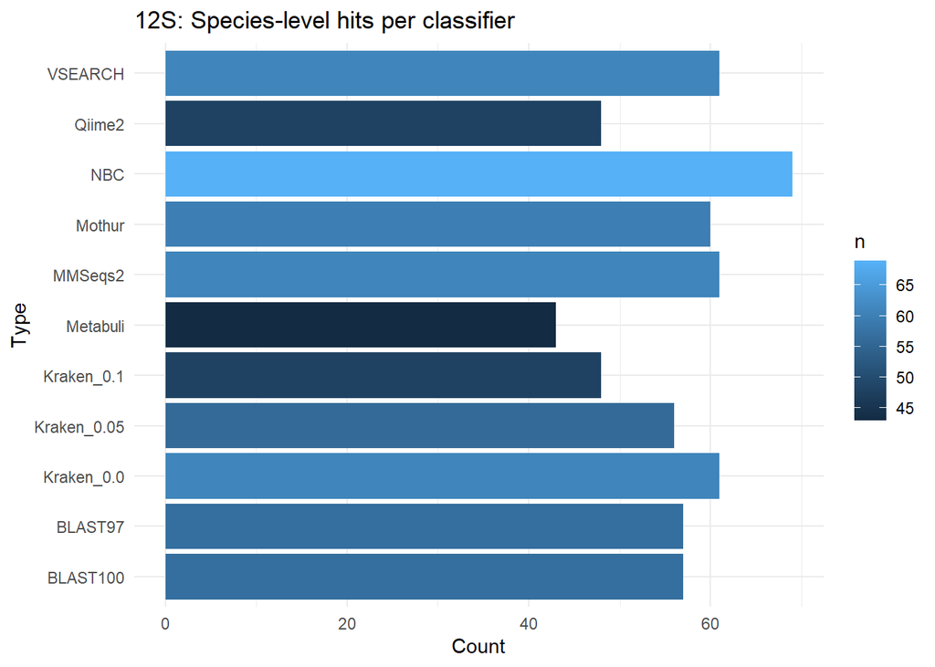

```r
twelveS_data_vs_12S_100 |> select(Type, species) |> filter(species != 'dropped' &
                                                             !is.na(species)) |>
  group_by(Type) |> count(species) |> summarise(n = n()) |>
  ggplot(aes(x = Type, y = n, fill = n)) + geom_col() + coord_flip() +
  theme_minimal() +
  ylab('Count') +
  ggtitle('12S: Species-level hits per classifier')
```

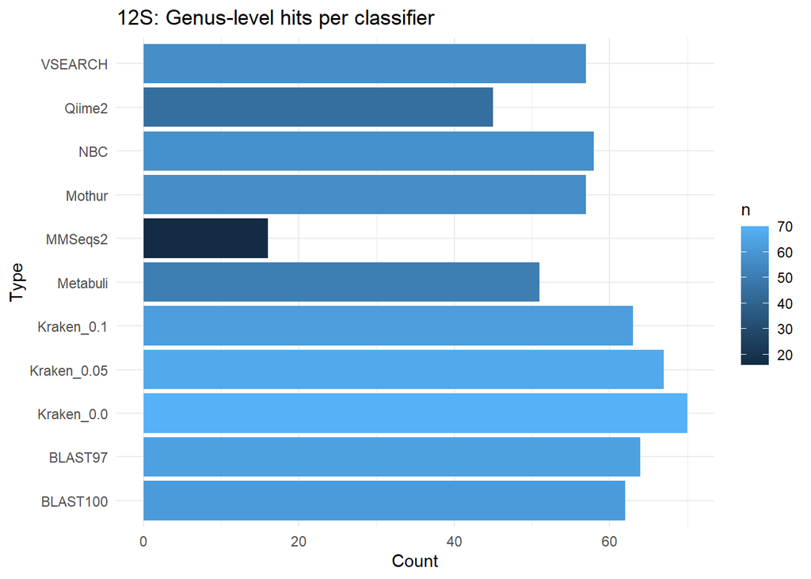

```r
twelveS_data_vs_12S_100 |> select(Type, genus) |> filter(genus != 'dropped' &
                                                             !is.na(genus)) |>
  group_by(Type) |> count(genus) |> summarise(n = n()) |>
  ggplot(aes(x = Type, y = n, fill = n)) + geom_col() + coord_flip() +
  theme_minimal() +
  ylab('Count') +
  ggtitle('12S: Genus-level hits per classifier')
```

```r
twelveS_truth <- truth |> filter(Query == 'make_12s_16s_simulated_reads_8-Rottnest_runEDNAFLOW_12S_RESULTS_dada2_asv.fa') |> select(OTU, family, species) |> rename(True_OTU = OTU, True_family = family, True_species = species)
head(twelveS_truth)
```

```
## # A tibble: 6 × 3
##   True_OTU True_family  True_species
##   <chr>    <chr>        <chr>
## 1 ASV_1    Syngnathidae Phyllopteryx taeniolatus
## 2 ASV_2    Syngnathidae Phycodurus eques
## 3 ASV_3    Syngnathidae Phyllopteryx taeniolatus
## 4 ASV_4    Labridae     dropped
## 5 ASV_5    Alopiidae    Isurus oxyrinchus
## 6 ASV_6    Carangidae   Seriola lalandi
```

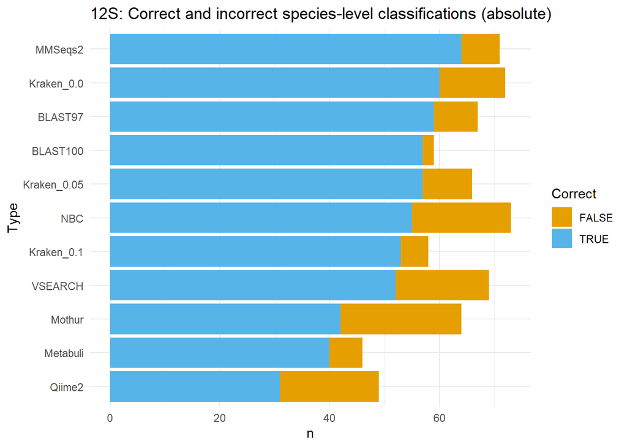

```r
twelveS_data_vs_12S_100 |> left_join(twelveS_truth, by = c('OTU' = 'True_OTU')) |>
  mutate(Correct = True_species == species) |>
  filter(species != 'dropped' & !is.na(species)) |>
  group_by(Type) |> count(Correct) |>
  ggplot(aes(x = fct_rev(fct_reorder2(Type, Correct, n)), fill = Correct, y = n))+ geom_col() +
  coord_flip() + theme_minimal() + xlab('Type') +
  ggtitle('12S: Correct and incorrect species-level classifications (absolute)') +
  scale_fill_manual(values = c("#E69F00", "#56B4E9", "#009E73",
          "#F0E442", "#0072B2", "#D55E00", "#CC79A7"))
```

```r
cols <- c('Correct species' = "#009E73", 'Correct genus'="#56B4E9", 'Correct family' = "#0072B2", 'Incorrect family' = "#E69F00", 'Incorrect genus'="#F0E442", 'Incorrect species'="#D55E00", 'No hit'= "#CC79A7")
```

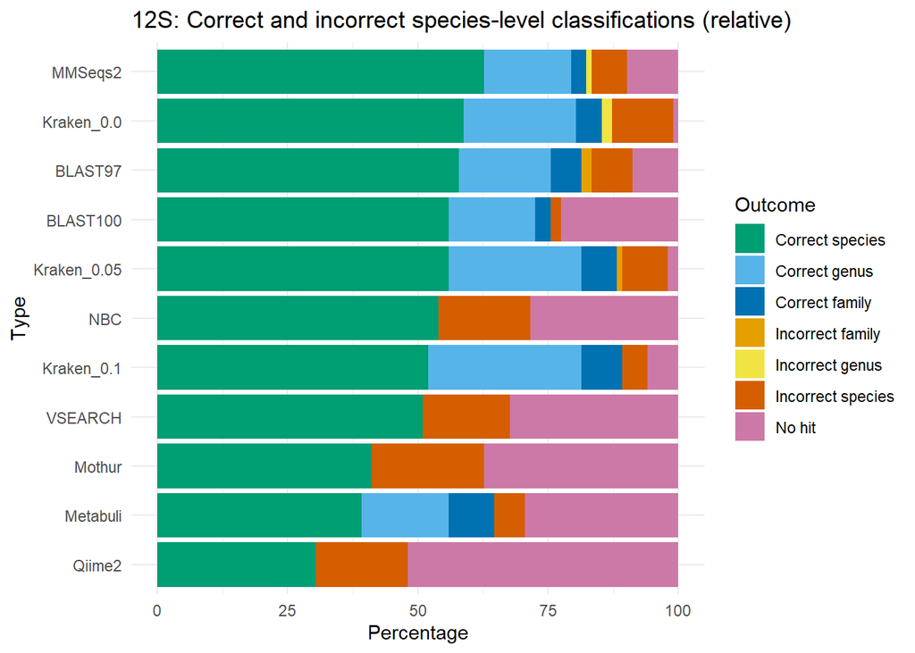

```r
twelve_s_relative_plot <- twelveS_data_vs_12S_100 |> left_join(twelveS_truth, by = c('OTU' = 'True_OTU')) |>
  separate(True_species, into = c('True_Genus', 'True_Epiteth'), remove = FALSE)|>
  mutate(species = na_if(species, 'dropped')) |>
  mutate(genus = na_if(genus, 'dropped')) |>

  mutate(CorrectSpecies = case_when(!is.na(species) & True_species == species ~ 'Correct species',
                              !is.na(species) & True_species != species ~ 'Incorrect species',
                              !is.na(genus) & !is.na(True_Genus) & True_Genus == genus ~ 'Correct genus',
                              !is.na(genus) & !is.na(True_Genus) & True_Genus != genus ~ 'Incorrect genus',
                              !is.na(family) & True_family == family ~ 'Correct family',
                              !is.na(family) & True_family != family ~ 'Incorrect family',
                              TRUE ~ NA)) |>
  group_by(Type) |>
  count(CorrectSpecies) |>
  mutate(total = sum(n, na.rm=TRUE)) |>
  mutate(missing = 102 - total) |>
  group_modify(~ add_row(.x)) |>
  group_modify(~ {
    .x |> mutate(new_col= max(missing, na.rm=TRUE)) |>
      mutate(n = case_when(is.na(CorrectSpecies) & is.na(missing) ~ new_col,
                                  TRUE ~ n)) |>
      select(-new_col)
  } ) |>
  mutate(total = 102) |>
  mutate(perc = n / total * 100) |>
  mutate(CorrectSpecies = replace_na(CorrectSpecies, 'No hit')) |>
  mutate(CorrectSpecies = factor(CorrectSpecies, rev(c('Correct species', 'Correct genus', 'Correct family', 'Incorrect family', 'Incorrect genus', 'Incorrect species', 'No hit')))) |>
  ggplot(aes(x = fct_rev(fct_reorder2(Type, CorrectSpecies, n)), fill = CorrectSpecies, y = perc))+
  geom_col() +
  coord_flip() +
  theme_minimal() +
  ylab('Percentage') + xlab('Type') +
  ggtitle('12S: Correct and incorrect species-level classifications (relative)') +
  scale_fill_manual(name = 'Outcome', values = cols, breaks=names(cols))
twelve_s_relative_plot
```

### Calculate Upset-based species sightings

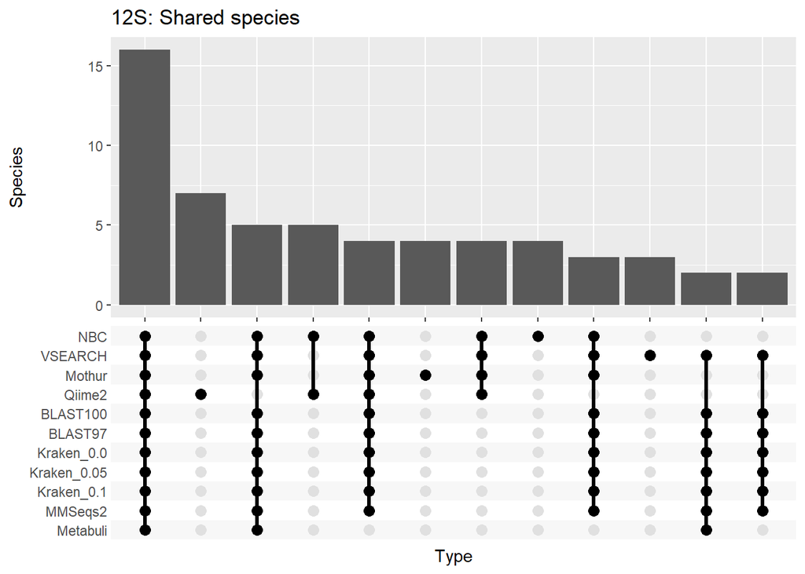

```r
type_list <- twelveS_data_vs_12S_100 |> select(Type, species) |> unique() |> filter(!is.na(species) & species != 'dropped') |>
  group_by(species) |>
  summarize('Type' = list(Type))

a <- type_list |>
  ggplot(aes(x = Type)) +
  geom_bar() +
  scale_x_upset(n_intersections = 12) +
  ggtitle('12S: Shared species') +
  ylab('Species')
a
```

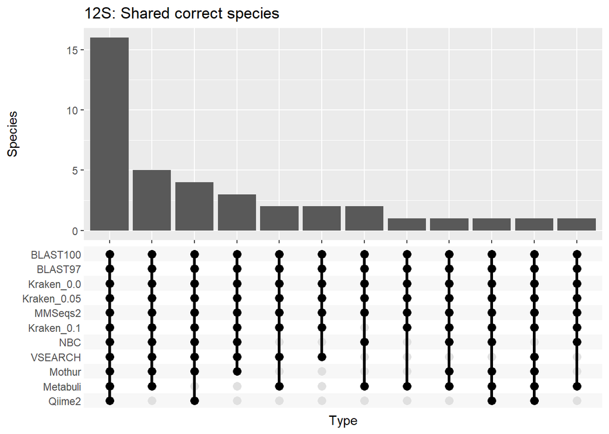

```r
type_list <- twelveS_data_vs_12S_100 |> left_join(twelveS_truth, by = c('OTU' = 'True_OTU')) |>
  filter(species == True_species) |>
  filter(species != 'dropped' & !is.na(species)) |>
  select(Type, species) |> unique() |>
  group_by(species) |>
  summarize('Type' = list(Type))

b <- type_list |>
  ggplot(aes(x = Type)) +
  geom_bar() +
  scale_x_upset(n_intersections = 12) +
  ggtitle('12S: Shared correct species') +
  ylab('Species')
b
```

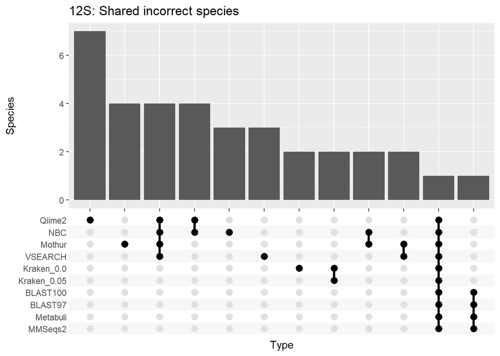

```r
type_list <- twelveS_data_vs_12S_100 |> left_join(twelveS_truth, by = c('OTU' = 'True_OTU')) |>
  filter(species != True_species) |>
  filter(species != 'dropped' & !is.na(species)) |>
  select(Type, species) |> unique() |>
  group_by(species) |>
  summarize('Type' = list(Type))

c <- type_list |>
  ggplot(aes(x = Type)) +
  geom_bar() +
  scale_x_upset(n_intersections = 12) +
  ggtitle('12S: Shared incorrect species') +
  ylab('Species')
c
```

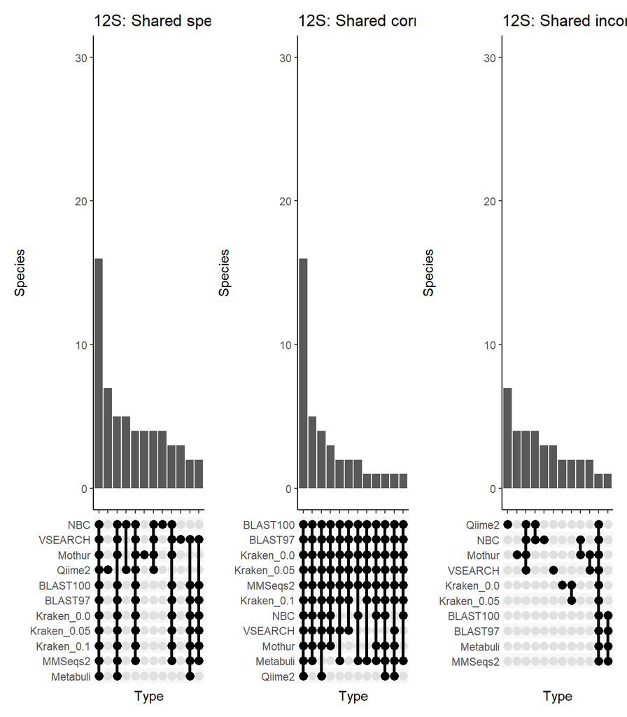

```r
a + b + c & ylim(c(0, 30)) &
  theme(
  # Hide panel borders and remove grid lines
  panel.border = element_blank(),
  panel.grid.major = element_blank(),
  panel.background = element_blank(),
  panel.grid.minor = element_blank(),
  #panel.grid.major.y = element_line(),
  # Change axis line
  axis.line = element_line(colour = "black")
  )
```

### Calculate FP/TP/TN/FN

```r
add_scores <- function(twelveS_data_vs_12S_100_with_MaxTruth, twelveS_truth ) {
  twelveS_data_vs_12S_100_with_MaxTruth|> left_join(twelveS_truth, by = c('OTU' = 'True_OTU')) |>
  separate(True_species, into = c('True_Genus', 'True_Epiteth'), remove = FALSE)|>
  mutate(species = na_if(species, 'dropped')) |>
  mutate(genus = na_if(genus, 'dropped')) |>

  mutate(CorrectSpecies = case_when(!is.na(species) & True_species == species ~ 'Correct species',
                              !is.na(species) & True_species != species ~ 'Incorrect species',
                              !is.na(genus) & !is.na(True_Genus) & True_Genus == genus ~ 'Correct genus',
                              !is.na(genus) & !is.na(True_Genus) & True_Genus != genus ~ 'Incorrect genus',
                              !is.na(family) & True_family == family ~ 'Correct family',
                              !is.na(family) & True_family != family ~ 'Incorrect family',
                              TRUE ~ NA)) |>
  group_by(Type) |>
  summarise(TP = sum(str_detect(CorrectSpecies, pattern='Correct species'), na.rm=TRUE),
            FP = sum(str_detect(CorrectSpecies, pattern = 'Incorrect species'), na.rm=TRUE),
            TN = sum(str_detect(replace_na(CorrectSpecies,'NA'), pattern='NA') & is.na(True_species), na.rm=TRUE),
            FN = sum(is.na(species) & !is.na(True_species))) |>
  mutate(sums = TP + FP + TN + FN) |>
  mutate(missing = 102 - sums) |>
  mutate(FN = FN + missing) |>
  mutate(sums = TP + FP + TN + FN) |>
  select(-c(missing, sums))
}
```

```r
scores <- add_scores(twelveS_data_vs_12S_100, twelveS_truth)
```

```r
scores <- scores |> rowwise() |> mutate(recall = recall(TP, FN), precision = precision(TP, FP),
                              f1 = f1(precision, recall), f0.5 = f0.5(precision, recall), accuracy = accuracy(TP, FP, FN, TN))
scores
```

```
## # A tibble: 11 × 10
## # Rowwise:
##    Type           TP    FP    TN    FN recall precision    f1  f0.5 accuracy
##    <chr>       <int> <int> <int> <dbl>  <dbl>     <dbl> <dbl> <dbl>    <dbl>
##  1 BLAST100       57     2     0    43  0.57      0.966 0.717 0.848    0.559
##  2 BLAST97        59     8     0    35  0.628     0.881 0.733 0.815    0.578
##  3 Kraken_0.0     60    12     0    30  0.667     0.833 0.741 0.794    0.588
##  4 Kraken_0.05    57     9     0    36  0.613     0.864 0.717 0.798    0.559
##  5 Kraken_0.1     53     5     0    44  0.546     0.914 0.684 0.805    0.520
##  6 MMSeqs2        64     7     0    31  0.674     0.901 0.771 0.844    0.627
##  7 Metabuli       40     6     0    56  0.417     0.870 0.563 0.714    0.392
##  8 Mothur         42    22     0    38  0.525     0.656 0.583 0.625    0.412
##  9 NBC            55    18     0    29  0.655     0.753 0.701 0.731    0.539
## 10 Qiime2         31    18     0    53  0.369     0.633 0.466 0.554    0.304
## 11 VSEARCH        52    17     0    33  0.612     0.754 0.675 0.720    0.510
```

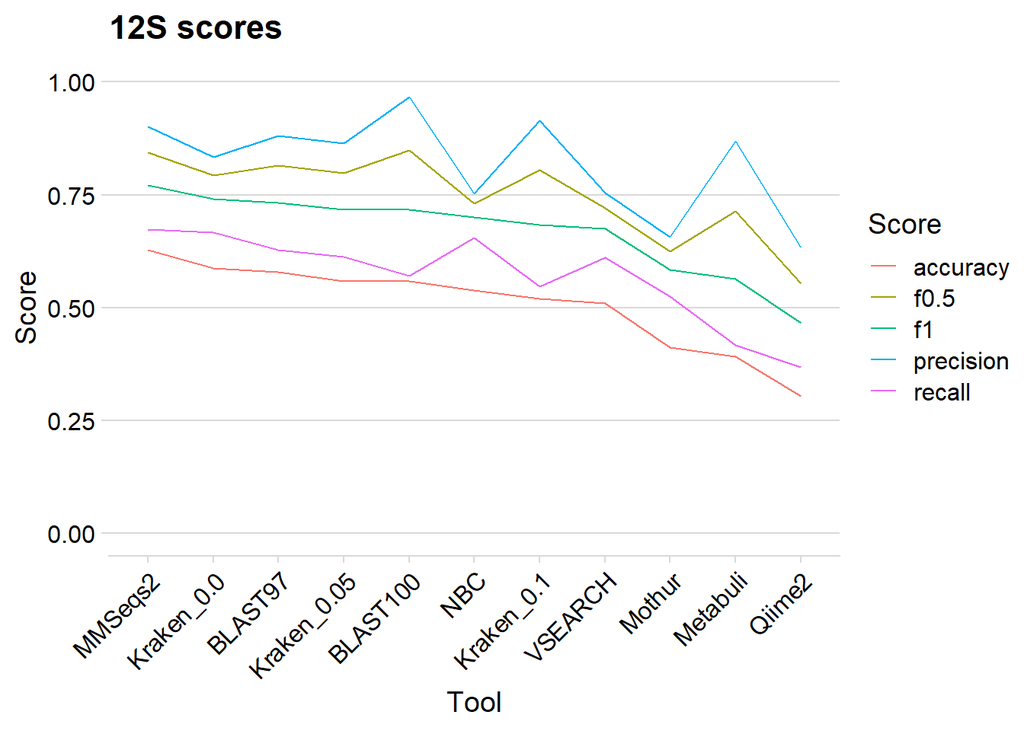

```r
twelveS_scoreS_plot <- scores |> select(-c(TP, FP, FN, TN)) |> pivot_longer(-Type, names_to='Score') |>  ggplot(aes(x = fct_rev(fct_reorder(Type, value)), y = value, group=Score, color = Score, fill =Score)) + geom_line() + ylim(c(0, 1))  + theme_minimal_hgrid()+ theme(axis.text.x = element_text( angle = 45, hjust = 1)) + ylab('Score') + xlab('Tool') + ggtitle('12S scores')
twelveS_scoreS_plot
```

#### Scores heatmap

Let’s also make a heatmap from that

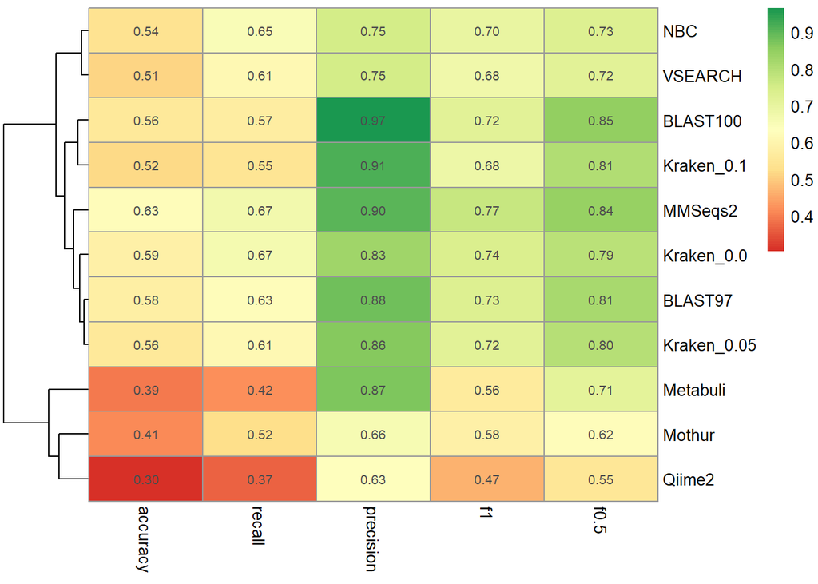

```r
b <- scores$Type
m <- scores |> select(-Type) |> select(accuracy, recall, precision, f1, f0.5) |> as.matrix()
rownames(m) <- b
pheatmap(m, cluster_cols=FALSE, display_numbers = TRUE,
         color = colorRampPalette(brewer.pal(n = 7, name =
  "RdYlGn"))(100))
```

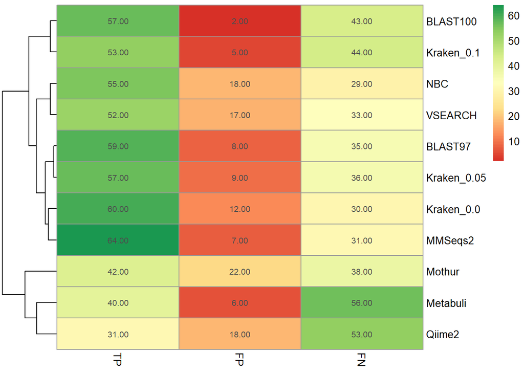

```r
b <- scores$Type
m <- scores |> select(-Type) |> select(TP, FP, FN) |> as.matrix()
rownames(m) <- b
pheatmap(m, cluster_cols=FALSE, display_numbers = TRUE,
         color = colorRampPalette(brewer.pal(n = 7, name =
  "RdYlGn"))(100))
```

### Metaclassifier

```r
table(twelveS_data_vs_12S_100$Type)
```

```
##
##    BLAST100     BLAST97  Kraken_0.0 Kraken_0.05  Kraken_0.1    Metabuli
##          79          93         102         102         102          75
##     MMSeqs2      Mothur         NBC      Qiime2     VSEARCH
##         102         102         102          49          69
```

First, we count the per-OTU species hits

```r
twelveS_data_vs_12S_100_maxCount <- twelveS_data_vs_12S_100 |>
  mutate(species = na_if(species, 'dropped')) |>
  filter(!is.na(species)) |>
  #filter(! Type %in% c('Mothur', 'VSEARCH', 'Kraken_0.2', 'Qiime2', 'Metabuli', 'NBC', 'BLAST97', 'Kraken_0.0', 'Kraken_0.1')) |>
  group_by(Query, Subject, OTU) |>
  count(species) |>
  # double check the truth
  #left_join(twelveS_truth, by = c('OTU' = 'True_OTU')) |>
  #mutate(Truth = True_species == species) |>
  # pull out the per-group highest n
  filter( n > 4) |>
  slice_max(n, n=1, with_ties = FALSE) |>
  mutate(Type = 'MaxCount', .before = 'Query') |>
  select(-n)
twelveS_data_vs_12S_100_maxCount
```

```
## # A tibble: 70 × 5
## # Groups:   Query, Subject, OTU [70]
##    Type     Query                                          Subject OTU   species
##    <chr>    <chr>                                          <chr>   <chr> <chr>
##  1 MaxCount make_12s_16s_simulated_reads_8-Rottnest_runED… 12s_v0… ASV_1 Phyllo…
##  2 MaxCount make_12s_16s_simulated_reads_8-Rottnest_runED… 12s_v0… ASV_… Carcha…
##  3 MaxCount make_12s_16s_simulated_reads_8-Rottnest_runED… 12s_v0… ASV_… Isurus…
##  4 MaxCount make_12s_16s_simulated_reads_8-Rottnest_runED… 12s_v0… ASV_… Acanth…
##  5 MaxCount make_12s_16s_simulated_reads_8-Rottnest_runED… 12s_v0… ASV_… Pseudo…
##  6 MaxCount make_12s_16s_simulated_reads_8-Rottnest_runED… 12s_v0… ASV_… Parupe…
##  7 MaxCount make_12s_16s_simulated_reads_8-Rottnest_runED… 12s_v0… ASV_… Sphyrn…
##  8 MaxCount make_12s_16s_simulated_reads_8-Rottnest_runED… 12s_v0… ASV_… Parupe…
##  9 MaxCount make_12s_16s_simulated_reads_8-Rottnest_runED… 12s_v0… ASV_… Chaeto…
## 10 MaxCount make_12s_16s_simulated_reads_8-Rottnest_runED… 12s_v0… ASV_… Dascyl…
## # ℹ 60 more rows
```

```r
twelveS_data_vs_12S_100_with_MaxTruth <- twelveS_data_vs_12S_100 |>
  bind_rows(twelveS_data_vs_12S_100_maxCount) #|>
  #filter(! Type %in% c('Mothur', 'VSEARCH', 'Kraken_0.2', 'Qiime2', 'Metabuli', 'NBC', 'BLAST97', 'Kraken_0.0', 'Kraken_0.1'))
```

```r
maxTruth_scores <-  add_scores(twelveS_data_vs_12S_100_with_MaxTruth, twelveS_truth )
```

```r
maxTruth_scores <- maxTruth_scores |> rowwise() |> mutate(recall = recall(TP, FN), precision = precision(TP, FP),
                              f1 = f1(precision, recall), f0.5 = f0.5(precision, recall), accuracy = accuracy(TP, FP, FN, TN))
```

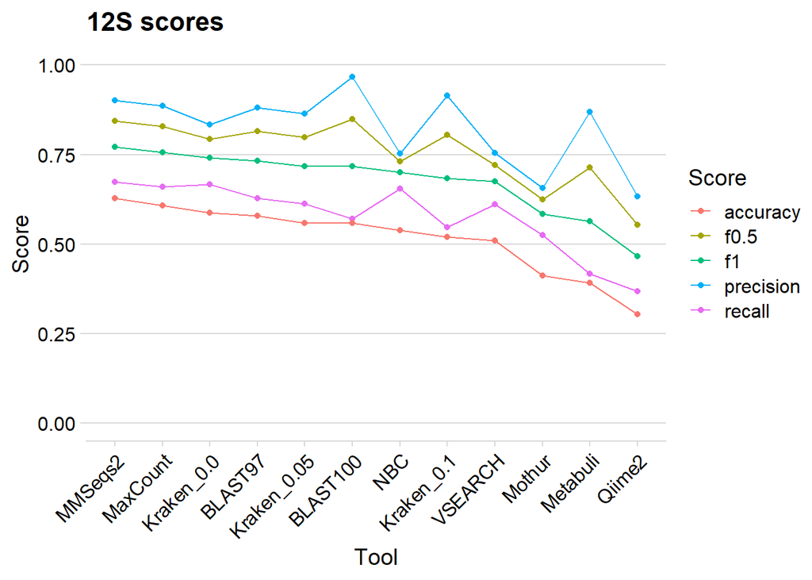

```r
maxTruth_scoreS_plot <- maxTruth_scores |> select(-c(TP, FP, FN, TN)) |> pivot_longer(-Type, names_to='Score') |>  ggplot(aes(x = fct_rev(fct_reorder(Type, value)), y = value, group=Score, color = Score, fill =Score)) + geom_line() + ylim(c(0, 1))  + theme_minimal_hgrid()+ theme(axis.text.x = element_text( angle = 45, hjust = 1)) + ylab('Score') + xlab('Tool') + geom_point() + ggtitle('12S scores')
maxTruth_scoreS_plot
```

With the Rottnest data MaxCount performs slightly better! But still not as good as MMSeqs2….

## 16S

```r
sixteenS_truth <- truth |> filter(Query == 'make_12s_16s_simulated_reads_8-Rottnest_runEDNAFLOW_16S_RESULTS_dada2_asv.fa') |> select(OTU, family, species) |> rename(True_OTU = OTU, True_family = family, True_species = species)
tail(sixteenS_truth)
```

```
## # A tibble: 6 × 3
##   True_OTU True_family    True_species
##   <chr>    <chr>          <chr>
## 1 ASV_106  Alopiidae      Isurus oxyrinchus
## 2 ASV_107  Carangidae     Seriola dumerili
## 3 ASV_108  Carcharhinidae Sphyrna lewini
## 4 ASV_109  Scombridae     Auxis thazard
## 5 ASV_110  Syngnathidae   Phycodurus eques
## 6 ASV_111  Syngnathidae   Phyllopteryx taeniolatus
```

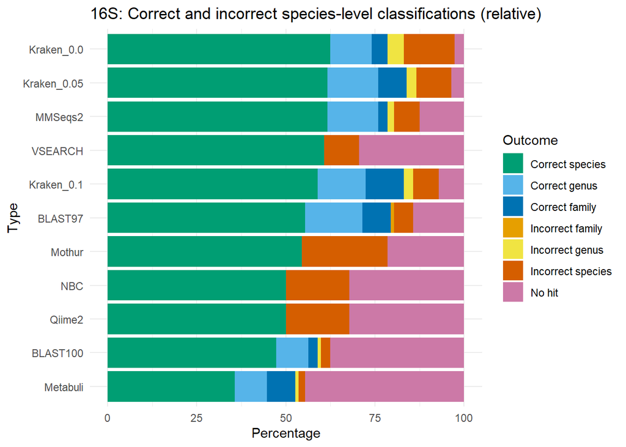

```r
sixteenS_relative_plot <- sixteenS_data_vs_16S_100 |> left_join(sixteenS_truth, by = c('OTU' = 'True_OTU')) |>
 separate(True_species, into = c('True_Genus', 'True_Epiteth'), remove = FALSE)|>
  mutate(species = na_if(species, 'dropped')) |>
  mutate(genus = na_if(genus, 'dropped')) |>

  mutate(CorrectSpecies = case_when(!is.na(species) & True_species == species ~ 'Correct species',
                              !is.na(species) & True_species != species ~ 'Incorrect species',
                              !is.na(genus) & !is.na(True_Genus) & True_Genus == genus ~ 'Correct genus',
                              !is.na(genus) & !is.na(True_Genus) & True_Genus != genus ~ 'Incorrect genus',
                              !is.na(family) & True_family == family ~ 'Correct family',
                              !is.na(family) & True_family != family ~ 'Incorrect family',
                              TRUE ~ NA)) |>
  group_by(Type) |>
  count(CorrectSpecies) |>
  mutate(total = sum(n)) |>
  mutate(missing = 112 - total) |>
  group_modify(~ add_row(.x)) |>
  group_modify(~ {
    .x |> mutate(new_col= max(missing, na.rm=TRUE)) |>
      mutate(n = case_when(is.na(CorrectSpecies) & is.na(missing) ~ new_col,
                                  TRUE ~ n)) |>
      select(-new_col)
  } ) |>
  mutate(total = 112) |>
  mutate(perc = n / total * 100) |>
  mutate(CorrectSpecies = replace_na(CorrectSpecies, 'No hit')) |>
  mutate(CorrectSpecies = factor(CorrectSpecies, rev(c('Correct species', 'Correct genus', 'Correct family', 'Incorrect family', 'Incorrect genus', 'Incorrect species', 'No hit')))) |>
  tidyr::complete(CorrectSpecies, fill = list(n=0, total = 112, missing = NA, perc = 0)) |>
  ggplot(aes(x = fct_rev(fct_reorder2(Type, CorrectSpecies, n)), fill = CorrectSpecies, y = perc))+
  geom_col() +
  coord_flip() +
  theme_minimal() +
  ylab('Percentage') + xlab('Type') +
  ggtitle('16S: Correct and incorrect species-level classifications (relative)') +
  scale_fill_manual(name = 'Outcome', values = cols, breaks=names(cols))
sixteenS_relative_plot
```

### Calculate scores

```r
scores <- add_scores(sixteenS_data_vs_16S_100, sixteenS_truth)
scores
```

```
## # A tibble: 11 × 5
##    Type           TP    FP    TN    FN
##    <chr>       <int> <int> <int> <dbl>
##  1 BLAST100       53     3     0    46
##  2 BLAST97        62     6     2    32
##  3 Kraken_0.0     70    16     2    14
##  4 Kraken_0.05    69    11     2    20
##  5 Kraken_0.1     66     8     2    26
##  6 MMSeqs2        69     8     2    23
##  7 Metabuli       40     2     1    59
##  8 Mothur         61    27     2    12
##  9 NBC            56    20     2    24
## 10 Qiime2         56    20     1    25
## 11 VSEARCH        68    11     1    22
```

```r
scores <- scores |> rowwise() |> mutate(recall = recall(TP, FN), precision = precision(TP, FP),
                              f1 = f1(precision, recall), f0.5 = f0.5(precision, recall), accuracy = accuracy(TP, FP, FN, TN))
scores
```

```
## # A tibble: 11 × 10
## # Rowwise:
##    Type           TP    FP    TN    FN recall precision    f1  f0.5 accuracy
##    <chr>       <int> <int> <int> <dbl>  <dbl>     <dbl> <dbl> <dbl>    <dbl>
##  1 BLAST100       53     3     0    46  0.535     0.946 0.684 0.820    0.520
##  2 BLAST97        62     6     2    32  0.660     0.912 0.765 0.847    0.627
##  3 Kraken_0.0     70    16     2    14  0.833     0.814 0.824 0.818    0.706
##  4 Kraken_0.05    69    11     2    20  0.775     0.862 0.817 0.844    0.696
##  5 Kraken_0.1     66     8     2    26  0.717     0.892 0.795 0.851    0.667
##  6 MMSeqs2        69     8     2    23  0.75      0.896 0.817 0.862    0.696
##  7 Metabuli       40     2     1    59  0.404     0.952 0.567 0.749    0.402
##  8 Mothur         61    27     2    12  0.836     0.693 0.758 0.718    0.618
##  9 NBC            56    20     2    24  0.7       0.737 0.718 0.729    0.569
## 10 Qiime2         56    20     1    25  0.691     0.737 0.713 0.727    0.559
## 11 VSEARCH        68    11     1    22  0.756     0.861 0.805 0.837    0.676
```

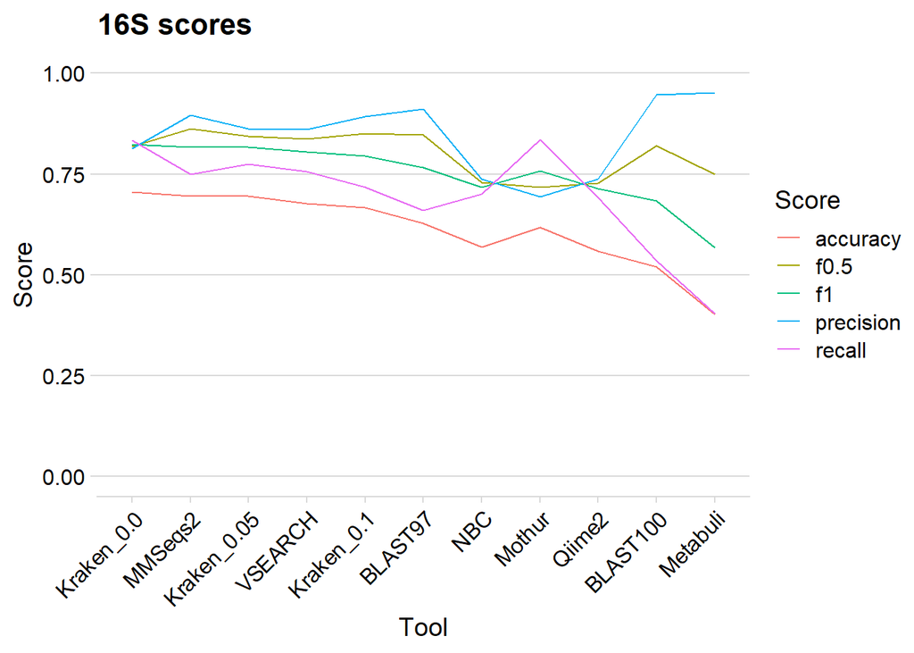

```r
sixteenS_score_plot <- scores |> select(-c(TP, FP, FN, TN)) |> pivot_longer(-Type, names_to='Score') |>  ggplot(aes(x = fct_rev(fct_reorder(Type, value)), y = value, group=Score, color = Score, fill =Score)) + geom_line() + ylim(c(0, 1))  + theme_minimal_hgrid() + theme(axis.text.x = element_text( angle = 45, hjust = 1)) + ylab('Score') + xlab('Tool') +  ggtitle('16S scores')
sixteenS_score_plot
```

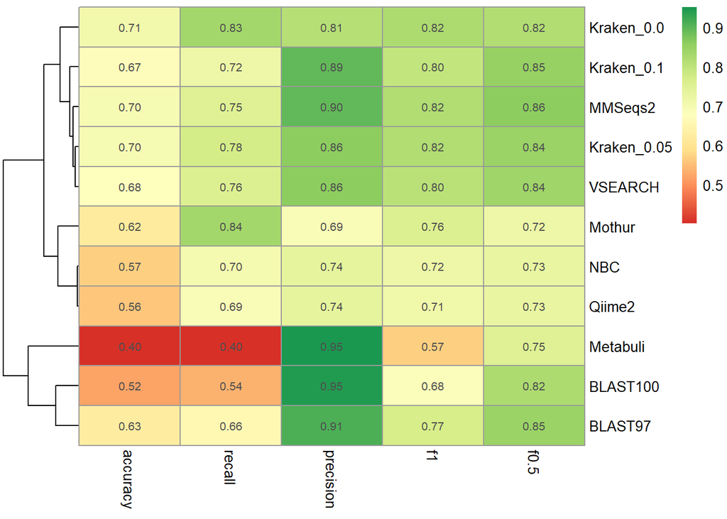

```r
b <- scores$Type
m <- scores |> select(-Type) |> select(accuracy, recall, precision, f1, f0.5) |> as.matrix()
rownames(m) <- b
pheatmap(m, cluster_cols=FALSE, display_numbers = TRUE,
         color = colorRampPalette(brewer.pal(n = 7, name =
  "RdYlGn"))(100))
```

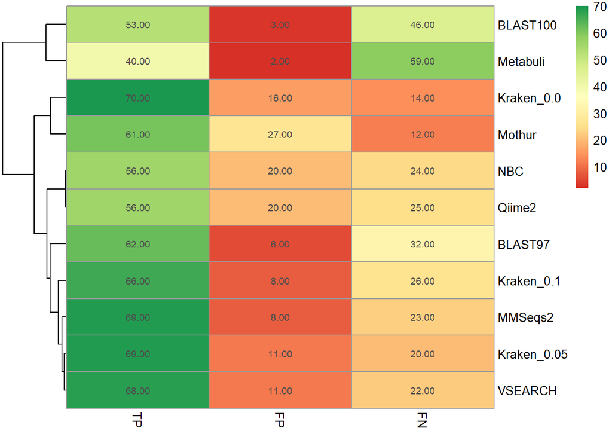

```r
b <- scores$Type
m <- scores |> select(-Type) |> select(TP, FP, FN) |> as.matrix()
rownames(m) <- b
pheatmap(m, cluster_cols=FALSE, display_numbers = TRUE,
         color = colorRampPalette(brewer.pal(n = 7, name =
  "RdYlGn"))(100))
```

### Calculate Upset-based species sightings

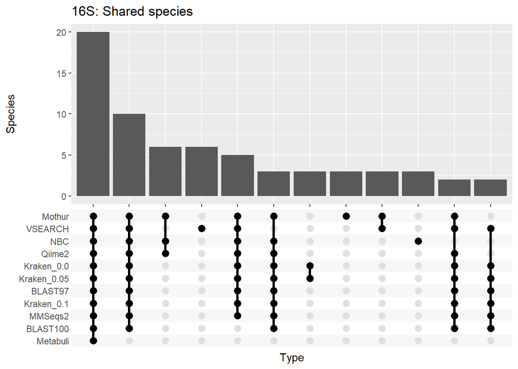

```r
type_list <- sixteenS_data_vs_16S_100  |> select(Type, species) |> unique() |> filter(!is.na(species) & species != 'dropped') |>
  group_by(species) |>
  summarize('Type' = list(Type))

a <- type_list |>
  ggplot(aes(x = Type)) +
  geom_bar() +
  scale_x_upset(n_intersections = 12) +
  ggtitle('16S: Shared species') +
  ylab('Species')
a
```

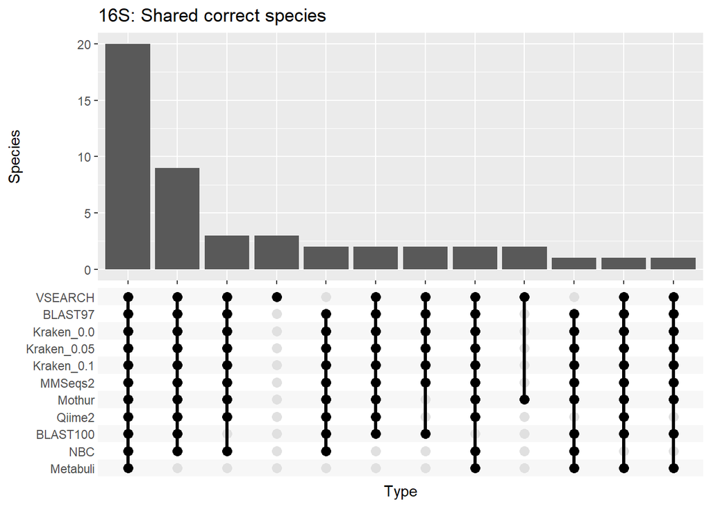

```r
type_list <- sixteenS_data_vs_16S_100 |> left_join(sixteenS_truth,  by = c('OTU' = 'True_OTU')) |>
  filter(species == True_species) |>
  filter(species != 'dropped' & !is.na(species)) |>
  select(Type, species) |> unique() |>
  group_by(species) |>
  summarize('Type' = list(Type))

b <- type_list |>
  ggplot(aes(x = Type)) +
  geom_bar() +
  scale_x_upset(n_intersections = 12) +
  ggtitle('16S: Shared correct species') +
  ylab('Species')
b
```

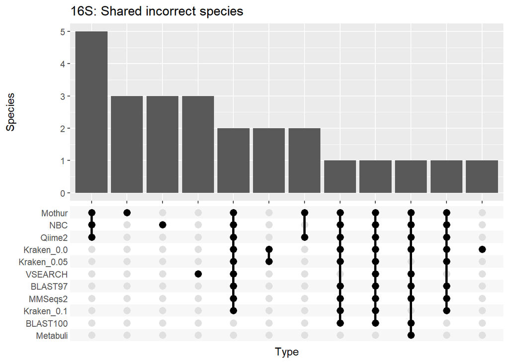

```r
type_list <- sixteenS_data_vs_16S_100 |> left_join(sixteenS_truth, by = c('OTU' = 'True_OTU')) |>
  filter(species != True_species) |>
  filter(species != 'dropped' & !is.na(species)) |>
  select(Type, species) |> unique() |>
  group_by(species) |>
  summarize('Type' = list(Type))

c <- type_list |>
  ggplot(aes(x = Type)) +
  geom_bar() +
  scale_x_upset(n_intersections = 12) +
  ggtitle('16S: Shared incorrect species') +
  ylab('Species')
c
```

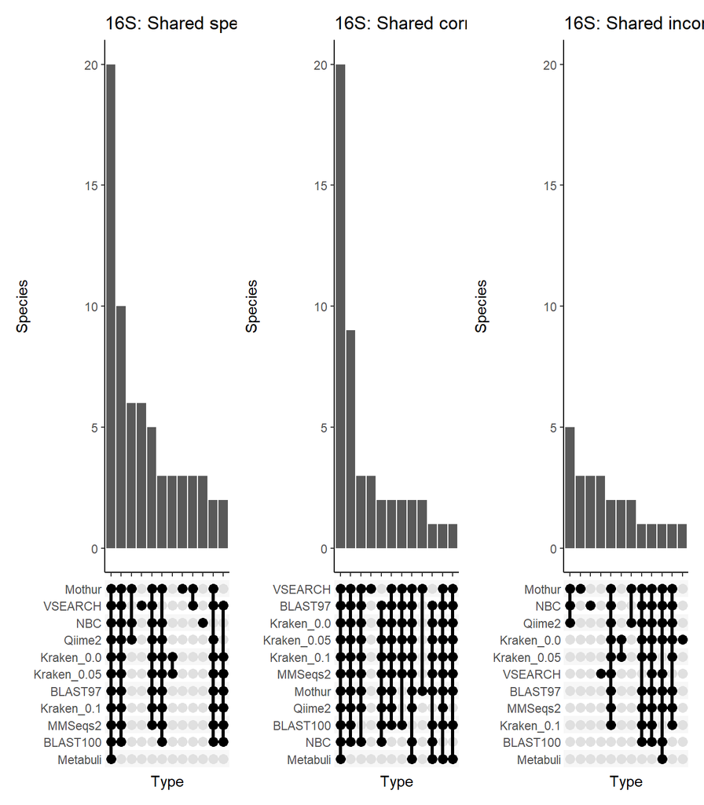

```r
a + b + c & ylim(c(0, 20)) &
  theme(
  # Hide panel borders and remove grid lines
  panel.border = element_blank(),
  panel.grid.major = element_blank(),
  panel.background = element_blank(),
  panel.grid.minor = element_blank(),
  #panel.grid.major.y = element_line(),
  # Change axis line
  axis.line = element_line(colour = "black")
  )
```

## 16S/12S relative plots

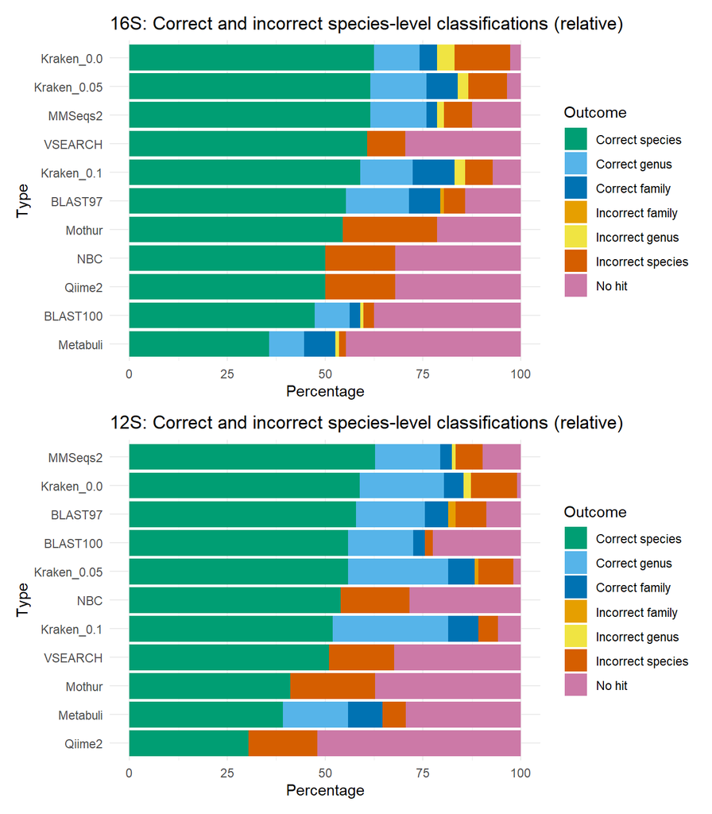

```r
sixteenS_relative_plot / twelve_s_relative_plot
```

Let’s make without titles, but with a/b

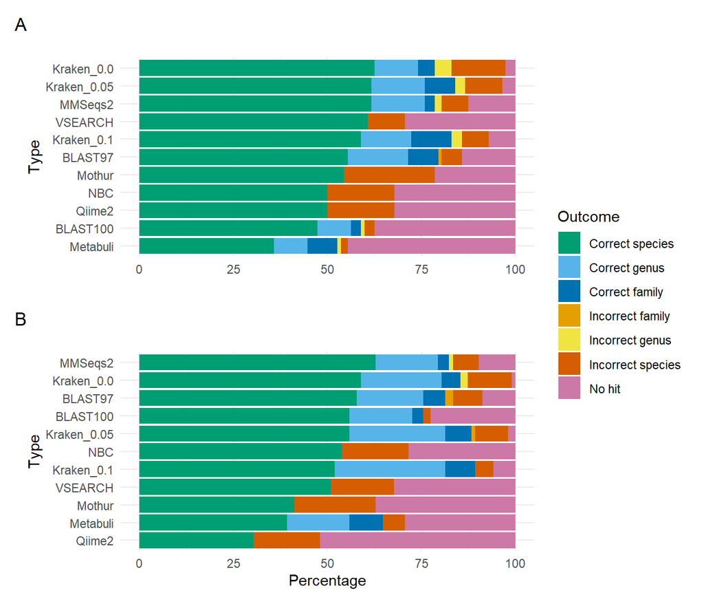

```r
(sixteenS_relative_plot + ggtitle('') + ylab(''))/ (twelve_s_relative_plot + ggtitle('')) +
  plot_annotation(tag_levels = c('A','B')) +
  plot_layout(guides = 'collect')
```

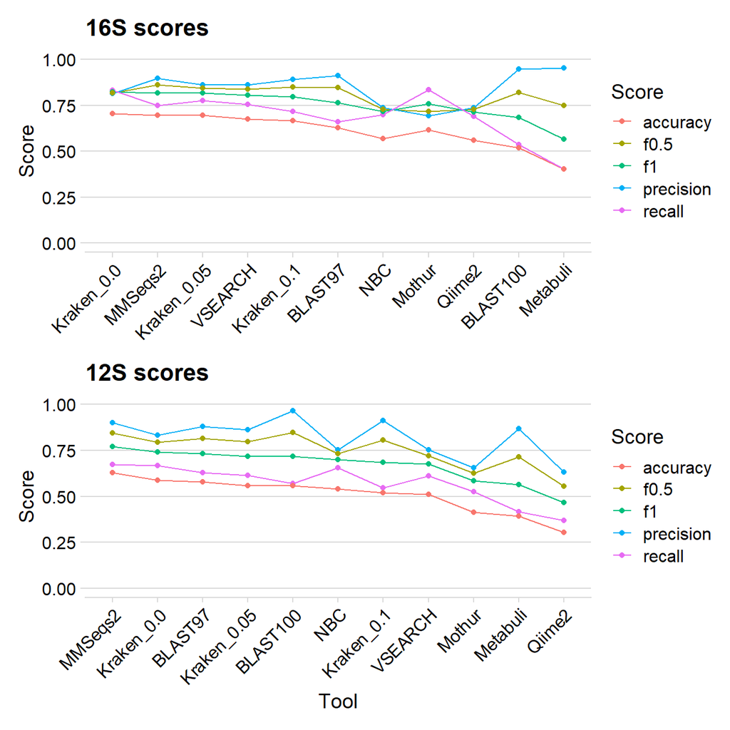

```r
(sixteenS_score_plot +geom_point() + theme(axis.title.x = element_blank()))/ (twelveS_scoreS_plot + geom_point())
```

## 12S exclusion databases

```r
twelve_exclusions <- data |> filter(str_starts(Subject, '12s_v010_final.fasta_Taxonomies.CountedFams.txt_')) |>
  filter(Query == 'make_12s_16s_simulated_reads_8-Rottnest_runEDNAFLOW_12S_RESULTS_dada2_asv.fa')
table(twelve_exclusions$Subject)
```

```
##
##    12s_v010_final.fasta_Taxonomies.CountedFams.txt_fifty_subset_1.fasta
##                                                                     840
##   12s_v010_final.fasta_Taxonomies.CountedFams.txt_fifty_subset_10.fasta
##                                                                     844
##    12s_v010_final.fasta_Taxonomies.CountedFams.txt_fifty_subset_2.fasta
##                                                                     860
##    12s_v010_final.fasta_Taxonomies.CountedFams.txt_fifty_subset_3.fasta
##                                                                     837
##    12s_v010_final.fasta_Taxonomies.CountedFams.txt_fifty_subset_4.fasta
##                                                                     811
##    12s_v010_final.fasta_Taxonomies.CountedFams.txt_fifty_subset_5.fasta
##                                                                     845
##    12s_v010_final.fasta_Taxonomies.CountedFams.txt_fifty_subset_6.fasta
##                                                                     819
##    12s_v010_final.fasta_Taxonomies.CountedFams.txt_fifty_subset_7.fasta
##                                                                     827
##    12s_v010_final.fasta_Taxonomies.CountedFams.txt_fifty_subset_8.fasta
##                                                                     875
##    12s_v010_final.fasta_Taxonomies.CountedFams.txt_fifty_subset_9.fasta
##                                                                     852
##  12s_v010_final.fasta_Taxonomies.CountedFams.txt_seventy_subset_1.fasta
##                                                                     888
## 12s_v010_final.fasta_Taxonomies.CountedFams.txt_seventy_subset_10.fasta
##                                                                     865
##  12s_v010_final.fasta_Taxonomies.CountedFams.txt_seventy_subset_2.fasta
##                                                                     857
##  12s_v010_final.fasta_Taxonomies.CountedFams.txt_seventy_subset_3.fasta
##                                                                     882
##  12s_v010_final.fasta_Taxonomies.CountedFams.txt_seventy_subset_4.fasta
##                                                                     889
##  12s_v010_final.fasta_Taxonomies.CountedFams.txt_seventy_subset_5.fasta
##                                                                     919
##  12s_v010_final.fasta_Taxonomies.CountedFams.txt_seventy_subset_6.fasta
##                                                                     851
##  12s_v010_final.fasta_Taxonomies.CountedFams.txt_seventy_subset_7.fasta
##                                                                     920
##  12s_v010_final.fasta_Taxonomies.CountedFams.txt_seventy_subset_8.fasta
##                                                                     856
##  12s_v010_final.fasta_Taxonomies.CountedFams.txt_seventy_subset_9.fasta
##                                                                     873
##   12s_v010_final.fasta_Taxonomies.CountedFams.txt_thirty_subset_1.fasta
##                                                                     775
##  12s_v010_final.fasta_Taxonomies.CountedFams.txt_thirty_subset_10.fasta
##                                                                     758
##   12s_v010_final.fasta_Taxonomies.CountedFams.txt_thirty_subset_2.fasta
##                                                                     757
##   12s_v010_final.fasta_Taxonomies.CountedFams.txt_thirty_subset_3.fasta
##                                                                     730
##   12s_v010_final.fasta_Taxonomies.CountedFams.txt_thirty_subset_4.fasta
##                                                                     725
##   12s_v010_final.fasta_Taxonomies.CountedFams.txt_thirty_subset_5.fasta
##                                                                     775
##   12s_v010_final.fasta_Taxonomies.CountedFams.txt_thirty_subset_6.fasta
##                                                                     727
##   12s_v010_final.fasta_Taxonomies.CountedFams.txt_thirty_subset_7.fasta
##                                                                     742
##   12s_v010_final.fasta_Taxonomies.CountedFams.txt_thirty_subset_8.fasta
##                                                                     754
##   12s_v010_final.fasta_Taxonomies.CountedFams.txt_thirty_subset_9.fasta
##                                                                     804
```

```r
twelve_exclusions_split <- twelve_exclusions |> separate(Subject, into = c('before', 'hit'), sep='.txt_') |>
  # get rid of leftover non-subsetted databases
  filter(!is.na(hit)) |>
  separate(hit, into=c('Database', 'after'), sep='_subset')
```

```r
twelve_exclusions_split_averaged <- twelve_exclusions_split |> left_join(twelveS_truth, by = c('OTU' = 'True_OTU')) |>
  separate(True_species, into = c('True_Genus', 'True_Epiteth'), remove = FALSE)|>
  mutate(species = na_if(species, 'dropped')) |>
  mutate(genus = na_if(genus, 'dropped')) |>

  mutate(CorrectSpecies = case_when(!is.na(species) & True_species == species ~ 'Correct species',
                              !is.na(species) & True_species != species ~ 'Incorrect species',
                              !is.na(genus) & !is.na(True_Genus) & True_Genus == genus ~ 'Correct genus',
                              !is.na(genus) & !is.na(True_Genus) & True_Genus != genus ~ 'Incorrect genus',
                              !is.na(family) & True_family == family ~ 'Correct family',
                              !is.na(family) & True_family != family ~ 'Incorrect family',
                              TRUE ~ NA)) |>
  group_by(Type, Database, after) |>
  summarise(TP = sum(str_detect(CorrectSpecies, pattern='Correct species'), na.rm=TRUE),
            FP = sum(str_detect(CorrectSpecies, pattern = 'Incorrect species'), na.rm=TRUE),
            TN = sum(str_detect(replace_na(CorrectSpecies,'NA'), pattern='NA') & is.na(True_species), na.rm=TRUE),
            FN = sum(is.na(species) & !is.na(True_species))) |>
  mutate(sums = TP + FP + TN + FN) |>
  mutate(missing = 102 - sums) |>
  mutate(FN = FN + missing) |>
  mutate(sums = TP + FP + TN + FN) |>
  select(-c(missing, sums)) |>
  group_by(Type, Database) |>
  summarise(mean_TP = mean(TP),
            mean_FP = mean(FP),
            mean_TN = mean(TN),
            mean_FN = mean(FN)) |>
  rowwise() |>
  mutate(recall = recall(mean_TP, mean_FN),
         precision = precision(mean_TP, mean_FP),
         f1 = f1(precision, recall),
         f0.5 = f0.5(precision, recall),
         accuracy = accuracy(mean_TP, mean_FP, mean_FN, mean_TN))
twelve_exclusions_split_averaged <- twelve_exclusions_split_averaged |>
  mutate(Database = case_when ( Database == 'fifty' ~ '50%',
                               Database == 'seventy' ~ '70%',
                               Database == 'thirty' ~ '30%',
                               TRUE ~ Database))
```

```r
f1_pl <- twelve_exclusions_split_averaged |>
  ggplot(aes(x = Type, y = f1, group = Database, color = Database, fill = Database)) +
  geom_point() +
  geom_line() +
  theme_minimal()
```

```r
f0.5_pl <- twelve_exclusions_split_averaged |>
  ggplot(aes(x = Type, y = f0.5, group = Database, color = Database, fill = Database)) +
  geom_point() +
  geom_line() +
  theme_minimal()
```

```r
precision_pl <- twelve_exclusions_split_averaged |>
  ggplot(aes(x = Type, y = precision, group = Database, color = Database, fill = Database)) +
  geom_point() +
  geom_line() +
  theme_minimal()
```

```r
recall_pl <- twelve_exclusions_split_averaged |>
  ggplot(aes(x = Type, y = recall, group = Database, color = Database, fill = Database)) +
  geom_point() +
  geom_line() +
  theme_minimal()
```

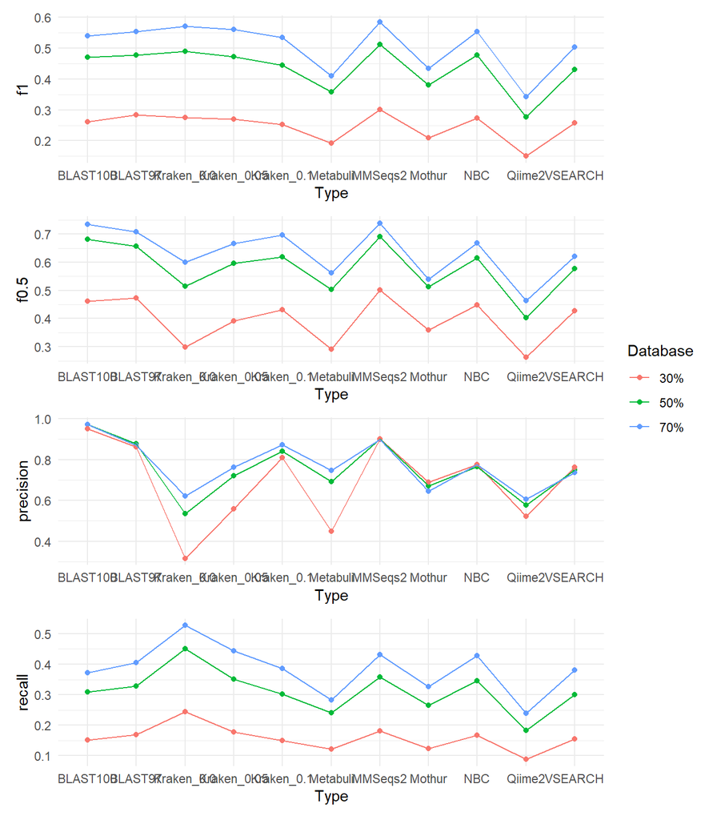

```r
(f1_pl / f0.5_pl / precision_pl / recall_pl) +  plot_layout(guides = 'collect')
```

Lets zero in on the precision and make boxplots with jitter dots

```r
un_summarised_twelve <- twelve_exclusions_split |> left_join(twelveS_truth, by = c('OTU' = 'True_OTU')) |>
  separate(True_species, into = c('True_Genus', 'True_Epiteth'), remove = FALSE)|>
  mutate(species = na_if(species, 'dropped')) |>
  mutate(genus = na_if(genus, 'dropped')) |>

  mutate(CorrectSpecies = case_when(!is.na(species) & True_species == species ~ 'Correct species',
                              !is.na(species) & True_species != species ~ 'Incorrect species',
                              !is.na(genus) & !is.na(True_Genus) & True_Genus == genus ~ 'Correct genus',
                              !is.na(genus) & !is.na(True_Genus) & True_Genus != genus ~ 'Incorrect genus',
                              !is.na(family) & True_family == family ~ 'Correct family',
                              !is.na(family) & True_family != family ~ 'Incorrect family',
                              TRUE ~ NA)) |>
  group_by(Type, Database, after) |>
  summarise(TP = sum(str_detect(CorrectSpecies, pattern='Correct species'), na.rm=TRUE),
            FP = sum(str_detect(CorrectSpecies, pattern = 'Incorrect species'), na.rm=TRUE),
            TN = sum(str_detect(replace_na(CorrectSpecies,'NA'), pattern='NA') & is.na(True_species), na.rm=TRUE),
            FN = sum(is.na(species) & !is.na(True_species))) |>
  mutate(sums = TP + FP + TN + FN) |>
  mutate(missing = 102 - sums) |>
  mutate(FN = FN + missing) |>
  mutate(sums = TP + FP + TN + FN) |>
  select(-c(missing, sums)) |>
  rowwise() |>
  mutate(recall = recall(TP, FN),
         precision = precision(TP, FP),
         f1 = f1(precision, recall),
         f0.5 = f0.5(precision, recall),
         accuracy = accuracy(TP, FP, FN, TN)) |>
  mutate(Database = case_when ( Database == 'fifty' ~ '50%',
                               Database == 'seventy' ~ '70%',
                               Database == 'thirty' ~ '30%',
                               TRUE ~ Database))
```

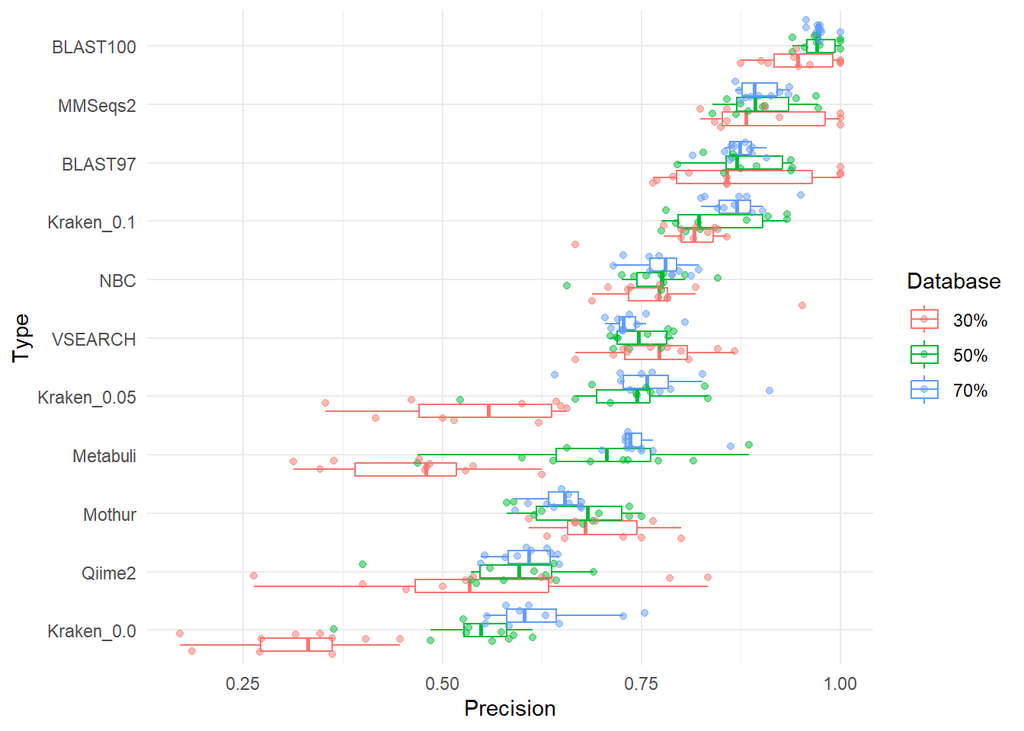

```r
un_summarised_twelve |> group_by(Type, Database) |> mutate(best = max(mean(precision))) |>
  ggplot(aes(x = fct_reorder(Type, best), group = interaction(Type, Database),  color=Database, y = precision)) +
  geom_boxplot(outlier.shape = NA) +
  coord_flip() +
  theme_minimal() +
  xlab('Type') +
  ylab('Precision') +
  geom_point(position = position_jitterdodge(), alpha=0.5)
```

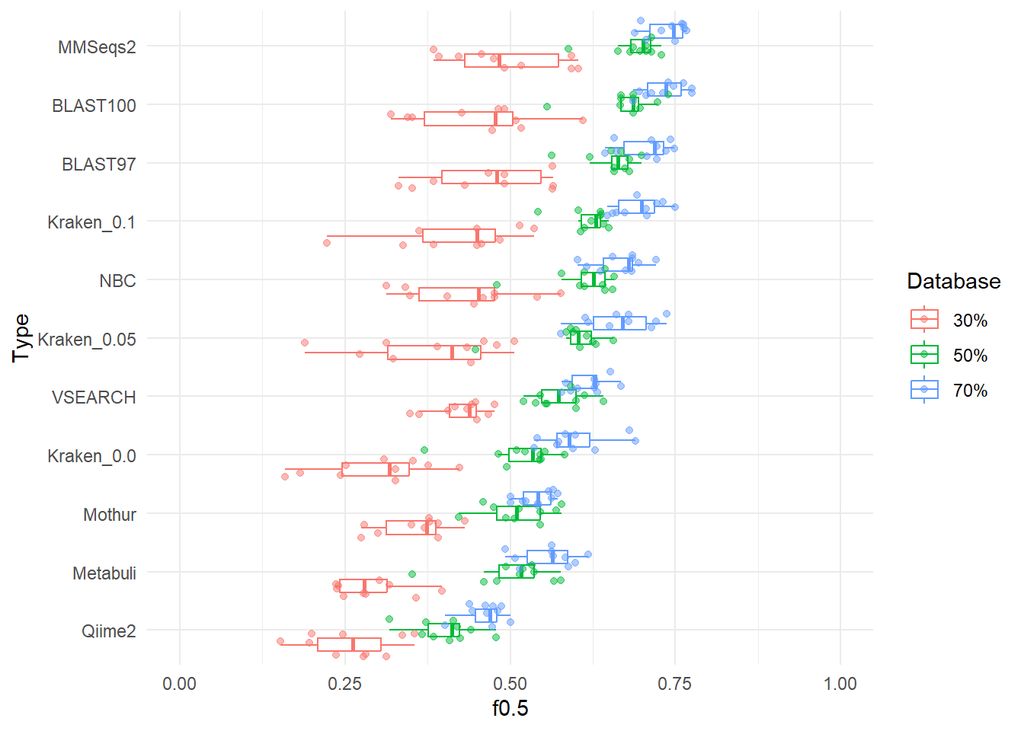

```r
un_summarised_twelve  |> group_by(Type, Database) |> mutate(best = max(mean(f0.5))) |>
  ggplot(aes(x = fct_reorder(Type, best), group = interaction(Type, Database), color=Database, y = f0.5)) +
  geom_boxplot(outlier.shape = NA) +
  coord_flip() +
  theme_minimal() +
  xlab('Type') +
  ylab('f0.5') +
  ylim(c(0, 1)) +
  geom_point(position = position_jitterdodge(), alpha=0.5)
```

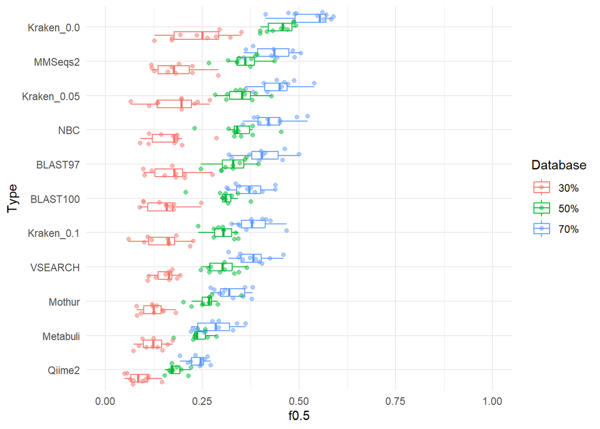

```r
un_summarised_twelve  |> group_by(Type, Database) |> mutate(best = max(mean(recall))) |>
  ggplot(aes(x = fct_reorder(Type, best), group = interaction(Type, Database), color=Database, y = recall)) +
  geom_boxplot(outlier.shape = NA) +
  coord_flip() +
  theme_minimal() +
  xlab('Type') +
  ylab('f0.5') +
  ylim(c(0, 1)) +
  geom_point(position = position_jitterdodge(), alpha=0.5)
```

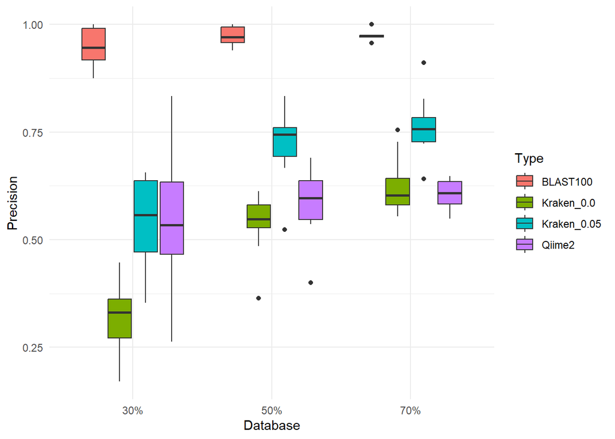

```r
un_summarised_twelve  |>
  filter(Type %in% c('BLAST100', 'Kraken_0.0', 'Kraken_0.05', 'Qiime2')) |>
  ggplot(aes(x=Database, y = precision, fill=Type)) + #fill=factor(Database, levels=c('30%','50%','70%')))) +
  geom_boxplot() +
  labs(fill='Type') +
  ylab('Precision') +
  theme_minimal()
```

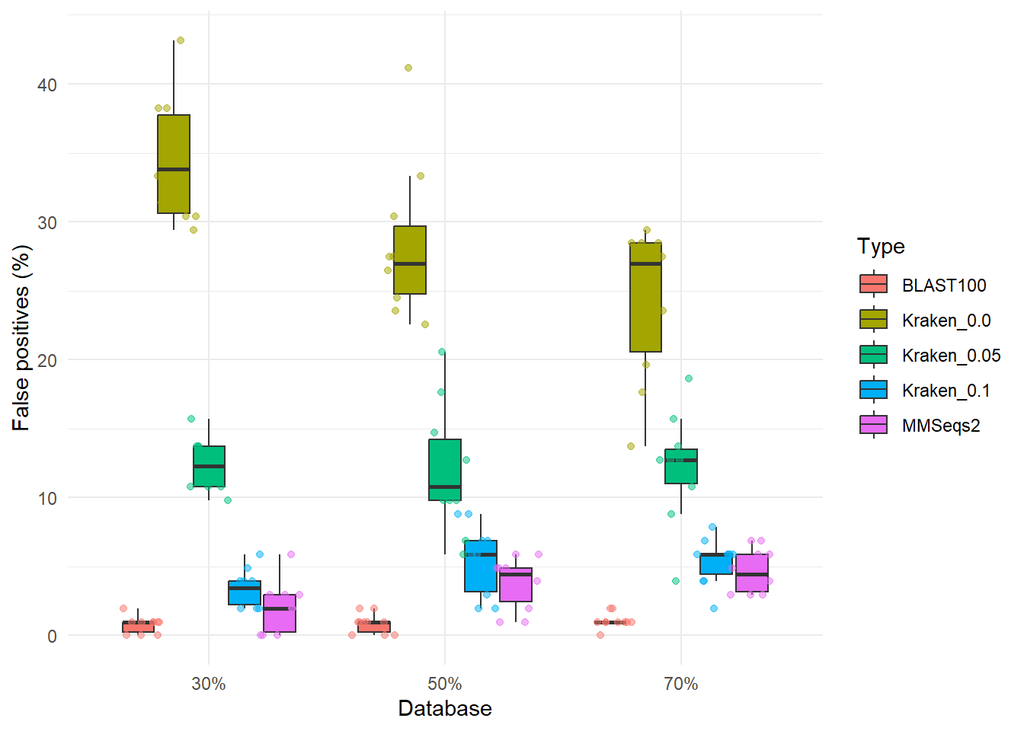

```r
false_positives <- un_summarised_twelve  |>
  filter(Type %in% c('BLAST100', 'Kraken_0.0', 'Kraken_0.05', 'Kraken_0.1', 'MMSeqs2')) |>
  ggplot(aes(x=Database, y = FP/102*100, fill=Type)) + #fill=factor(Database, levels=c('30%','50%','70%')))) +
  geom_boxplot(outlier.shape=NA) +
  labs(fill='Type') +
  ylab('False positives (%)') +
  geom_point(aes(color=Type),
             position = position_jitterdodge(jitter.width = 0.2),
             alpha=0.5,
             show.legend = FALSE)+
  theme_minimal()
false_positives
```

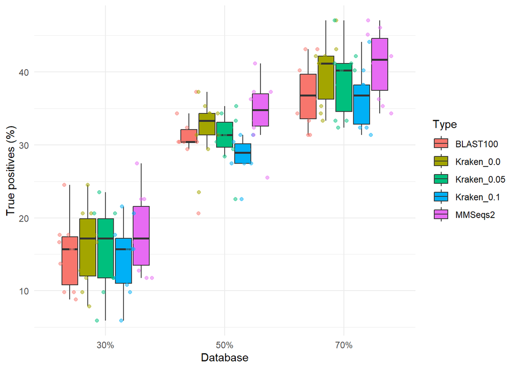

```r
true_positives <- un_summarised_twelve  |>
  filter(Type %in% c('BLAST100', 'Kraken_0.0', 'Kraken_0.05', 'Kraken_0.1', 'MMSeqs2')) |>
  ggplot(aes(x=Database, y = TP/102*100, fill=Type)) + #fill=factor(Database, levels=c('30%','50%','70%')))) +
  geom_boxplot(outlier.shape=NA) +
  labs(fill='Type') +
  ylab('True positives (%)') +
  geom_point(aes(color=Type),
           position = position_jitterdodge(jitter.width = 0.2),
           alpha=0.5,
           show.legend = FALSE)+
  theme_minimal()
true_positives
```

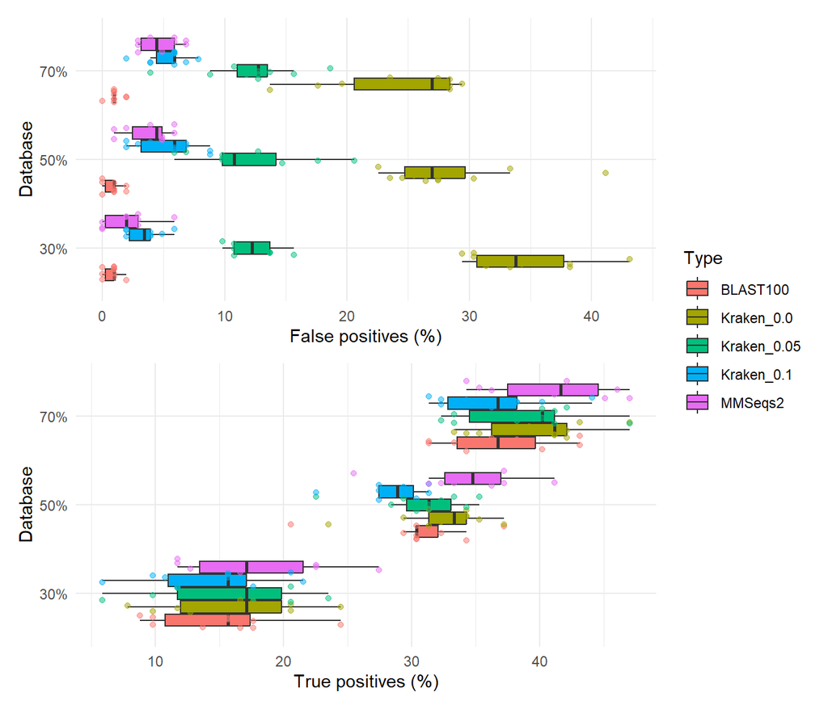

```r
false_positives/ true_positives + plot_layout(guides = 'collect') & coord_flip()
```

### Phylogenetic diversity